# Observational data recorded during daily walks

## Plot 1: Average vehicles by pedestrian group

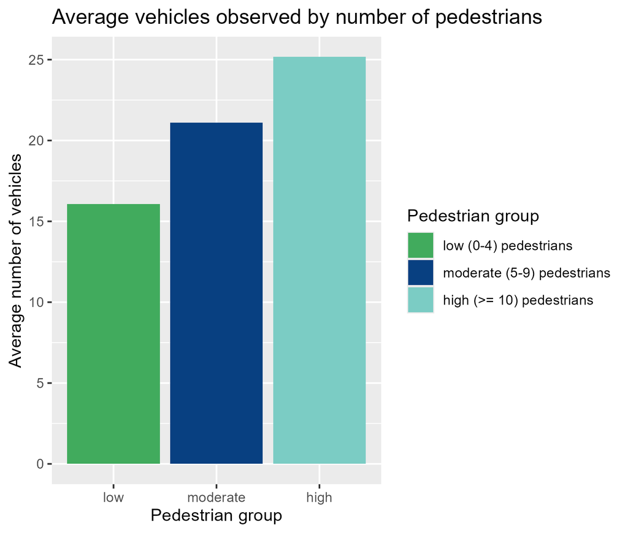

The bar graph above counts the average number of vehicles observed by pedestrian group, aiming to identify a correlation between number of pedestrians observed and vehicles observed.

We can observe a positive correlation between pedestrians observed and vehicles observed. Approximately 5 more vehicles are observed when comparing low to moderate and moderate to high pedestrian groups. Our graph suggests that during busy times of day, we can expect there to more pedestrians as well as vehicles compared to quieter times of day.

## Plot 2: Pedestrians by dataset

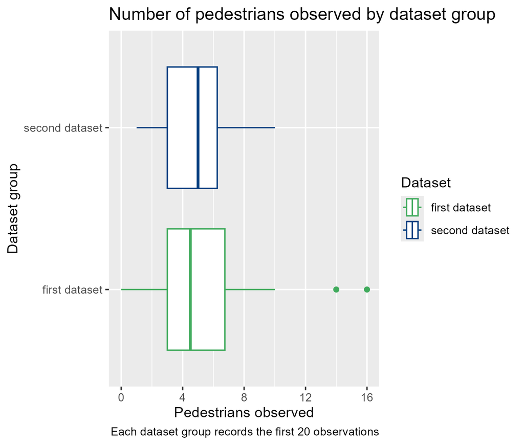

The first dataset group recorded observations from late March to early April when it was warmer, whereas the second dataset group recorded observations from early to late May when it was colder. The boxplot aims to determine if there is a noticeable difference between the two dataset groups when counting the number of pedestrians observed.

Both box plots are relatively similar, with the median, lower and upper quartiles placed in close proximity to each other. This suggests that there is no noticeable difference in pedestrians observed betwen the first and second datasets.

## Plot3: Vehicles by time

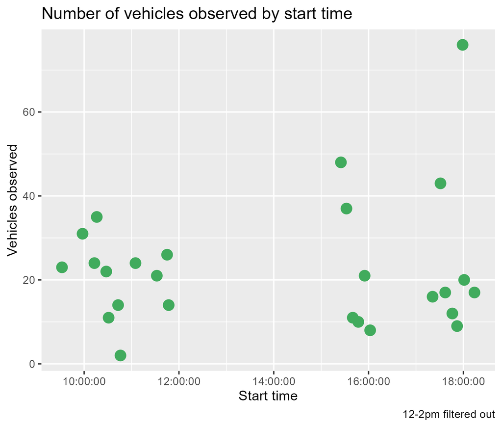

Scatter plot conveying a more spread out cluster in vehicles observed after 2pm, with a tighter cluster before 12pm

With the use of a scatterplot, we have portrayed the number of vehicles observed during different times of day. Notably, the vehicles observed between 12-2pm have been filtered out as the recipient of our data requested we remove these values as they are busy during these hours.

This creates two clusters of data. The first cluster is before 12pm and the second cluster is after 2pm. The second cluster is more spread out, whereas the first cluster is more compact. This indicates that there is more variation in the number of vehicles observed during the afternoon and evening compared to the morning.